# Predicting House Prices in Boulder

## Exploratory Analysis: Correlation Plots

The correlation plots below help us understand the relationship between home price and the different features discussed above.

### Correlation to Internal Characteristics

In these scatterplots, we see how newer homes have higher sales values. A possible explanation could be that older homes in this county might not have the same historical value as it does in cities like Washington DC or Philadelphia. As expected, homes with more bedrooms, bathrooms, and more square footage command higher prices.

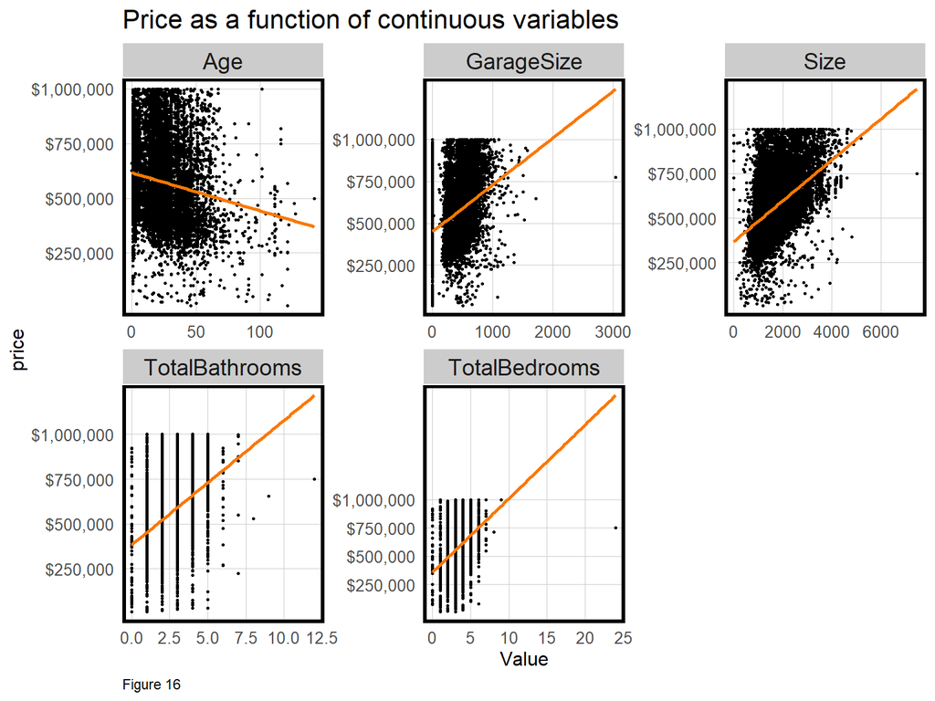

```r
#Internal Characteristics Correlation Plots
st_drop_geometry(boulder.sf) %>%
  mutate(Age = 2021 - YearBuilt) %>%
  dplyr::select(price, Size, Age, TotalBedrooms, TotalBathrooms, GarageSize) %>%
  filter(price <= 1000000, Age < 500) %>%
  gather(Variable, Value, -price) %>%
  ggplot(aes(Value, price)) +
    scale_y_continuous(breaks= c(250000,500000,750000,1000000),labels=c('$250,000','$500,000','$750,000','$1,000,000'))+
    geom_point(size = .5) +
    geom_smooth(method = "lm", se=F, colour = "#FA7800") +
    facet_wrap(~Variable, ncol = 3, scales = "free") +
    labs(title = "Price as a function of continuous variables", caption="Figure 16") +
    plotTheme()
```

### Correlation to Categorical Variables

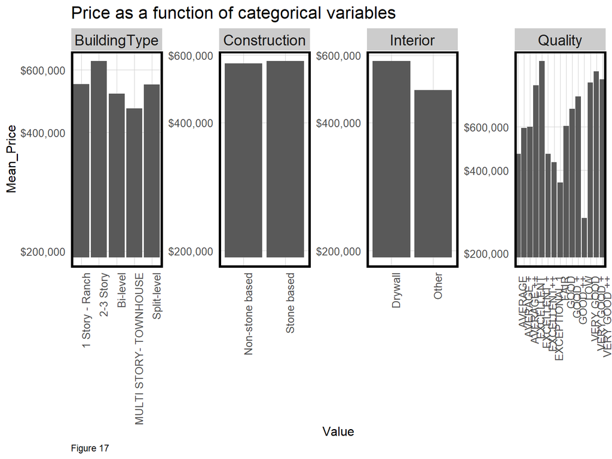

```r
boulder.sf <- boulder.sf %>% drop_na(Construction)
st_drop_geometry(boulder.sf) %>%
  dplyr::select(price, BuildingType, Quality, Construction, Interior) %>%
  filter(price <= 1000000) %>%
  gather(Variable, Value, -price) %>%
   ggplot(aes(Value, price)) +
  scale_y_continuous(breaks=c(20000,400000,600000), labels=c('$200,000','$400,000','$600,000'))+
     geom_bar(position = "dodge", stat = "summary", fun = "mean") +
     facet_wrap(~Variable, ncol = 4, scales = "free") +
     labs(title = "Price as a function of categorical variables", y = "Mean_Price",
          caption="Figure 17") +
     plotTheme() + theme(axis.text.x = element_text(angle = 90, hjust = 1))
```

The bar plots show that home sales prices varied based on the building typology, interior finishes and the quality rating from appraisers. While building type and material might be good features to include in a prediction model, the quality rating should be used cautiously, as there is a level of bias in the appraisals that the data may not reflect.

### Correlation to External Features

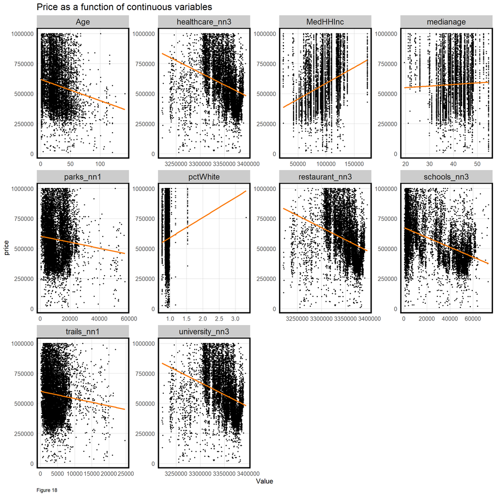

```r
st_drop_geometry(boulder.sf) %>%
  mutate(Age = 2021 - YearBuilt) %>%
  dplyr::select(price, Age, pctWhite, MedHHInc, medianage, parks_nn1, trails_nn1, schools_nn3, restaurant_nn3, university_nn3, healthcare_nn3) %>%
  filter(price <= 1000000, Age < 500) %>%
  gather(Variable, Value, -price) %>%
  ggplot(aes(Value, price)) +
    geom_point(size = .5) +
    geom_smooth(method = "lm", se=F, colour = "#FA7800") +
    facet_wrap(~Variable, ncol = 4, scales = "free") +
    labs(title = "Price as a function of continuous variables",
          caption="Figure 18") +
    plotTheme()
```

## Correlation Matrix

The correlation matrix below shows the variables’ relationship with each other. Since a home’s distance to restaurants, universities, and health care facilities were highly correlated with marijuana establishments, the three variables were excluded from the model.

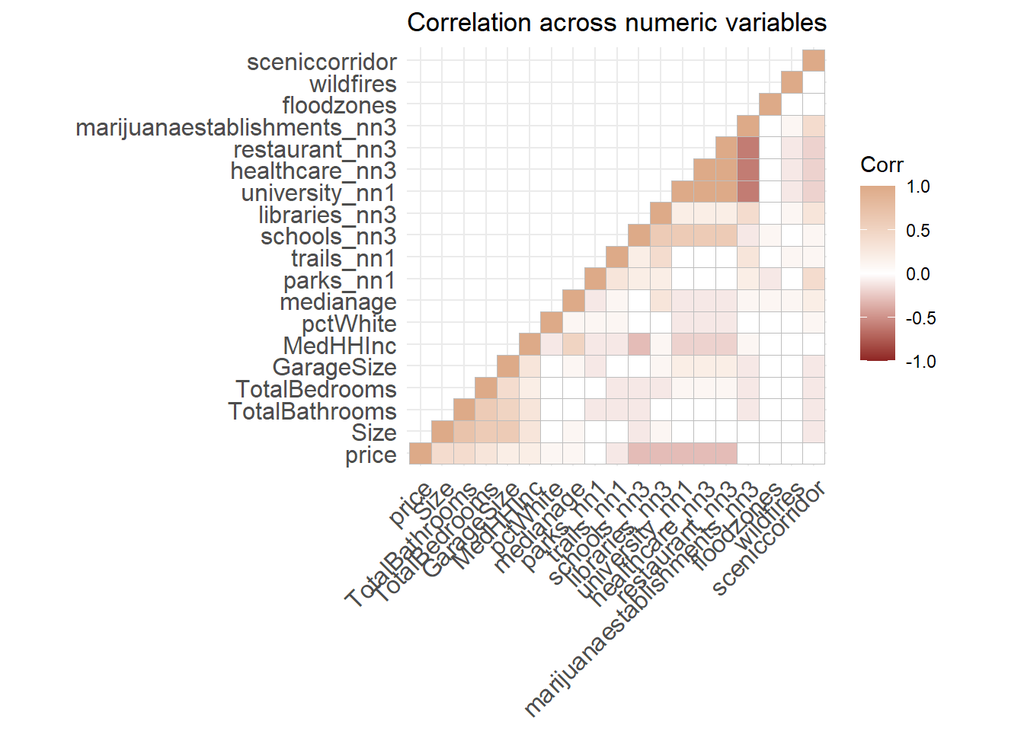

```r
corrplot <- st_drop_geometry(boulder.sf) %>%
  select(price, Size, TotalBathrooms, TotalBedrooms, GarageSize, MedHHInc, pctWhite, medianage, parks_nn1, trails_nn1, schools_nn3, libraries_nn3, university_nn1, healthcare_nn3, restaurant_nn3, marijuanaestablishments_nn3, floodzones, wildfires, sceniccorridor) %>% na.omit(na.action = "omit")

ggcorrplot(
  round(cor(corrplot), 1),
  p.mat = cor_pmat(corrplot),
  show.diag = TRUE,
  colors = c("#8d2323", "white", "#ddaa88"),
  type="lower",
  insig = "blank") +
    labs(title = "Correlation across numeric variables")
```

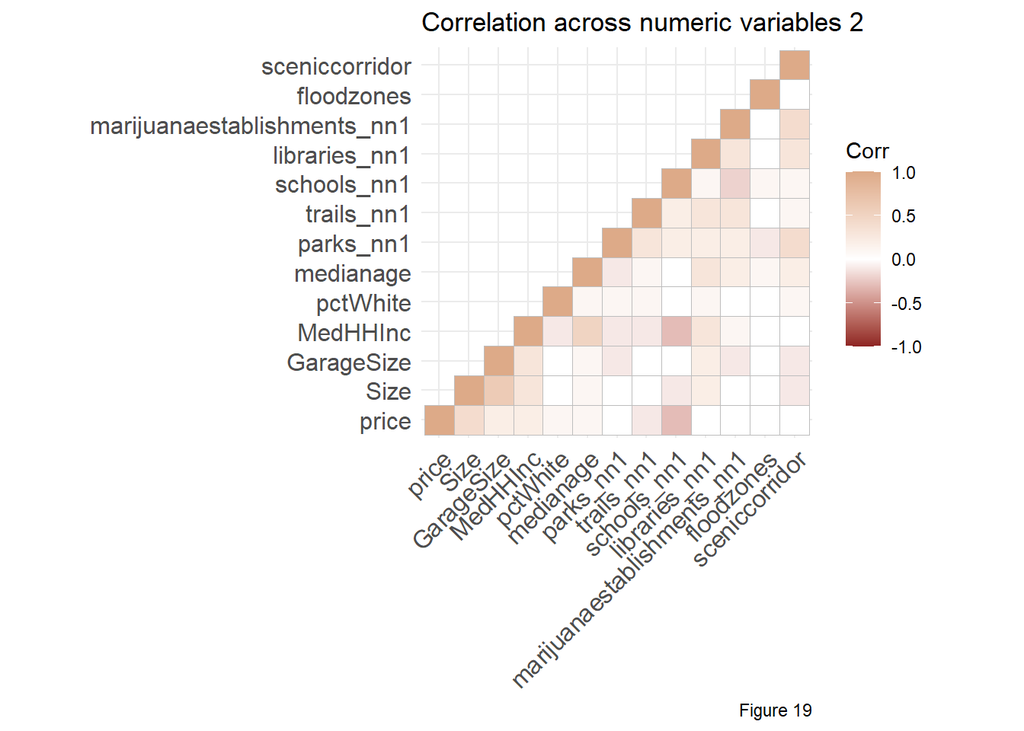

```r
corrplot2 <- st_drop_geometry(boulder.sf) %>%
  select(price, Size, GarageSize, MedHHInc, pctWhite, medianage, parks_nn1, trails_nn1, schools_nn1, libraries_nn1, marijuanaestablishments_nn1, floodzones, sceniccorridor) %>% na.omit(na.action = "omit")

ggcorrplot(
  round(cor(corrplot2), 1),
  p.mat = cor_pmat(corrplot2),
  show.diag = TRUE,
  colors = c("#8d2323", "white", "#ddaa88"),
  type="lower",
  insig = "blank") +
    labs(title = "Correlation across numeric variables 2",
         caption="Figure 19")
```